# Prediction Assignment Writeup

Suharkov MP

25 11 2020

## Overview

The goal of this project is to predict the manner in which people did the exercise. This is the “classe” variable in the training set. I will examine the data to choose the variables to predict with. This report is describing how I built the model, how I used cross validation, what the expected out of sample error is, and why I made these choices.

## Background

Using devices such as *Jawbone Up*, *Nike FuelBand*, and *Fitbit* it is now possible to collect a large amount of data about personal activity relatively inexpensively. These type of devices are part of the quantified self movement – a group of enthusiasts who take measurements about themselves regularly to improve their health, to find patterns in their behavior, or because they are tech geeks. One thing that people regularly do is quantify how *much* of a particular activity they do, but they rarely quantify *how well they do it*. In this project, your goal will be to use data from accelerometers on the belt, forearm, arm, and dumbell of 6 participants. They were asked to perform barbell lifts correctly and incorrectly in 5 different ways. More information is available from the website here: http:/groupware.les.inf.puc-rio.br/har (see the section on the Weight Lifting Exercise Dataset).

### Data source

The training data for this project are available here:

https://d396qusza40orc.cloudfront.net/predmachlearn/pml-training.csv

The test data are available here:

https://d396qusza40orc.cloudfront.net/predmachlearn/pml-testing.csv

## Libraries

```r
library(dplyr) #transforming data
library(ggplot2) #plotting
library(ggcorrplot) #plotting correlation matrix
library(caret) #machine learning
library(rattle) #plotting trees
```

### Seed

```r
set.seed(555)
```

## Get and clean the data

I will leave the test file for validation and in this project take 15% of train data for test purposes.

```r
data <- read.csv('https://d396qusza40orc.cloudfront.net/predmachlearn/pml-training.csv')
inTrain <- createDataPartition(y = data$classe, p = 0.85, list = FALSE)
training <- data[inTrain,]
testing <- data[-inTrain,]
validation <- read.csv('https://d396qusza40orc.cloudfront.net/predmachlearn/pml-testing.csv')
```

First look at the data:

```r
dim(training)
```

```
## [1] 16680   160
```

### How many rows of each class are there?

```r
proportions(table(training$classe))
```

```
##
##         A         B         C         D         E
## 0.2843525 0.1935252 0.1744005 0.1639089 0.1838129
```

All besides **A** are almost equal.

```r
str(training)
```

```
## 'data.frame':    16680 obs. of  160 variables:
##  $ X                       : int  1 2 3 4 5 6 7 8 10 11 ...
##  $ user_name               : chr  "carlitos" "carlitos" "carlitos" "carlitos" ...
##  $ raw_timestamp_part_1    : int  1323084231 1323084231 1323084231 1323084232 1323084232 1323084232 1323084232 1323084232 1323084232 1323084232 ...
##  $ raw_timestamp_part_2    : int  788290 808298 820366 120339 196328 304277 368296 440390 484434 500302 ...
##  $ cvtd_timestamp          : chr  "05/12/2011 11:23" "05/12/2011 11:23" "05/12/2011 11:23" "05/12/2011 11:23" ...
##  $ new_window              : chr  "no" "no" "no" "no" ...
##  $ num_window              : int  11 11 11 12 12 12 12 12 12 12 ...
##  $ roll_belt               : num  1.41 1.41 1.42 1.48 1.48 1.45 1.42 1.42 1.45 1.45 ...
##  $ pitch_belt              : num  8.07 8.07 8.07 8.05 8.07 8.06 8.09 8.13 8.17 8.18 ...
##  $ yaw_belt                : num  -94.4 -94.4 -94.4 -94.4 -94.4 -94.4 -94.4 -94.4 -94.4 -94.4 ...
##  $ total_accel_belt        : int  3 3 3 3 3 3 3 3 3 3 ...
##  $ kurtosis_roll_belt      : chr  "" "" "" "" ...
##  $ kurtosis_picth_belt     : chr  "" "" "" "" ...
##  $ kurtosis_yaw_belt       : chr  "" "" "" "" ...
```

[output cut: 86 more lines]

There are NA’s and empty cells in the dataset. Fill empty with NA’s for further processing:

```r
training <- training %>% na_if("")
```

The amount of NA’s in the train data can be estimated with this formula:

```r
sum(is.na(training)) / (dim(training)[1] * dim(training)[2])
```

```
## [1] 0.6122602
```

But this is a percentage of NA’s in all the data. Estimate the amount of rows. Showing all 160 columns’ NA’s will take several pages, I will show first 20% of them.

```r
sapply(training, function(x) sum(is.na(x)))[1:32]
```

```
##                    X            user_name raw_timestamp_part_1
##                    0                    0                    0
## raw_timestamp_part_2       cvtd_timestamp           new_window
##                    0                    0                    0
##           num_window            roll_belt           pitch_belt
##                    0                    0                    0
##             yaw_belt     total_accel_belt   kurtosis_roll_belt
##                    0                    0                16340
##  kurtosis_picth_belt    kurtosis_yaw_belt   skewness_roll_belt
##                16340                16340                16340
## skewness_roll_belt.1    skewness_yaw_belt        max_roll_belt
##                16340                16340                16340
##       max_picth_belt         max_yaw_belt        min_roll_belt
##                16340                16340                16340
##       min_pitch_belt         min_yaw_belt  amplitude_roll_belt
##                16340                16340                16340
## amplitude_pitch_belt   amplitude_yaw_belt var_total_accel_belt
##                16340                16340                16340
##        avg_roll_belt     stddev_roll_belt        var_roll_belt
##                16340                16340                16340
##       avg_pitch_belt    stddev_pitch_belt
##                16340                16340
```

```r
summary(training$max_roll_belt)[7] / dim(training)[1]
```

```
##      NA's
## 0.9796163
```

So, I will delete all columns with 95% and more NA’s:

```r
training <- training %>% select(which(colMeans(is.na(.)) < 0.95))
dim(training)
```

```
## [1] 16680    60
```

Looks nice, 60 variables are left out of 160. Now I get rid of variables with small variance and meaningless parameters like names, timestamps etc. First 7 columns are to be removed:

```r
training <- training[,8:60]
nearZeroVar(training)
```

```
## integer(0)
```

So, this data seems to be ok for creating models. Now the same manipulations with test data (in one string of code):

```r
testing <- select(testing, colnames(training))
validation <- select(validation, colnames(training)[1:52])
```

## Correlation matrix

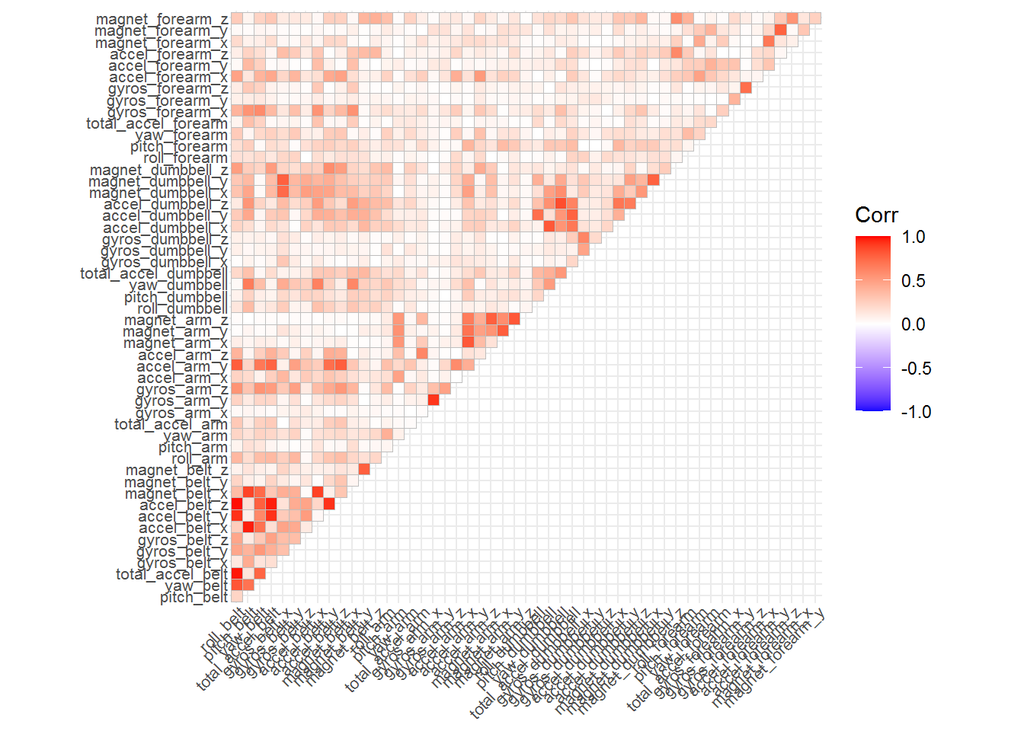

```r
p.mat <- abs(cor(training[,-53]))
ggcorrplot(p.mat, sig.level=0.05, lab_size = 4.5, p.mat = NULL, type = 'upper',
           insig = c('pch', 'blank'), pch = 1, pch.col = 'black', pch.cex = 1,
           tl.cex = 8) +
    theme(axis.text.x = element_text(margin = margin(-2, 0, 0, 0)),
          axis.text.y = element_text(margin = margin(0, -2, 0, 0)))
```

## What PCA will show?

```r
prComp <- prcomp(training[,-53])
summary(prComp)
```

```
## Importance of components:
##                             PC1      PC2      PC3      PC4       PC5       PC6
## Standard deviation     599.2168 532.5060 470.6777 376.9795 355.50681 254.76059
## Proportion of Variance   0.2641   0.2086   0.1629   0.1045   0.09296   0.04774
## Cumulative Proportion    0.2641   0.4727   0.6356   0.7401   0.83309   0.88082
##                              PC7       PC8       PC9      PC10     PC11
## Standard deviation     201.37465 173.87490 157.92046 118.28861 97.20550
## Proportion of Variance   0.02983   0.02224   0.01834   0.01029  0.00695
## Cumulative Proportion    0.91065   0.93289   0.95123   0.96152  0.96847
##                            PC12     PC13     PC14     PC15     PC16     PC17
## Standard deviation     89.33231 76.62254 68.44373 62.56378 56.74413 53.21737
## Proportion of Variance  0.00587  0.00432  0.00345  0.00288  0.00237  0.00208
## Cumulative Proportion   0.97434  0.97866  0.98210  0.98498  0.98735  0.98943
##                            PC18     PC19     PC20     PC21     PC22    PC23
## Standard deviation     49.67182 48.63546 41.46381 37.61411 35.11882 33.0102
## Proportion of Variance  0.00181  0.00174  0.00126  0.00104  0.00091  0.0008
## Cumulative Proportion   0.99125  0.99299  0.99425  0.99529  0.99620  0.9970
##                            PC24     PC25    PC26     PC27     PC28     PC29
## Standard deviation     30.65457 25.39384 23.1886 21.45926 20.76296 17.25401
## Proportion of Variance  0.00069  0.00047  0.0004  0.00034  0.00032  0.00022
## Cumulative Proportion   0.99769  0.99817  0.9986  0.99890  0.99922  0.99944
##                            PC30     PC31    PC32    PC33    PC34    PC35
## Standard deviation     15.14947 13.99758 9.95436 7.59764 7.27759 6.65358
## Proportion of Variance  0.00017  0.00014 0.00007 0.00004 0.00004 0.00003
## Cumulative Proportion   0.99961  0.99975 0.99982 0.99987 0.99990 0.99994
##                           PC36    PC37    PC38    PC39  PC40  PC41  PC42   PC43
## Standard deviation     6.13057 3.77477 3.52456 3.37583 2.123 1.935 1.106 0.5059
## Proportion of Variance 0.00003 0.00001 0.00001 0.00001 0.000 0.000 0.000 0.0000
## Cumulative Proportion  0.99996 0.99997 0.99998 0.99999 1.000 1.000 1.000 1.0000
##                          PC44   PC45   PC46   PC47   PC48   PC49   PC50   PC51
## Standard deviation     0.4202 0.3612 0.3172 0.3153 0.2397 0.1931 0.1841 0.1054
## Proportion of Variance 0.0000 0.0000 0.0000 0.0000 0.0000 0.0000 0.0000 0.0000
## Cumulative Proportion  1.0000 1.0000 1.0000 1.0000 1.0000 1.0000 1.0000 1.0000
##                           PC52
## Standard deviation     0.03676
## Proportion of Variance 0.00000
## Cumulative Proportion  1.00000
```

```r
prComp$center[1:10]
```

```
##        roll_belt       pitch_belt         yaw_belt total_accel_belt
##     64.240163669      0.348970624    -11.525839928     11.294844125
##     gyros_belt_x     gyros_belt_y     gyros_belt_z     accel_belt_x
##     -0.005407674      0.039563549     -0.129803357     -5.656594724
##     accel_belt_y     accel_belt_z
##     30.040827338    -72.290467626
```

## Comparing models

### Desicion tree with all columns

[figure not shown]

```r
tree1 <- train(classe ~ ., method = 'rpart', data = training)
fancyRpartPlot(tree1$finalModel)
```

```r
# Predicting new values
pred1 <- predict(tree1, newdata = testing)
confMat1 <- confusionMatrix(table(pred1, testing$classe))
confMat1
```

```
## Confusion Matrix and Statistics
##
##
## pred1   A   B   C   D   E
##     A 768 227 239 227  91
##     B  14 185  18  87  68
##     C  53 157 256 168 147
##     D   0   0   0   0   0
##     E   2   0   0   0 235
##
## Overall Statistics
##
##                Accuracy : 0.4908
##                  95% CI : (0.4726, 0.5091)
##     No Information Rate : 0.2845
##     P-Value [Acc > NIR] : < 2.2e-16
##
##                   Kappa : 0.3339
##
##  Mcnemar's Test P-Value : NA
##
## Statistics by Class:
##
##                      Class: A Class: B Class: C Class: D Class: E
## Sensitivity            0.9176  0.32513  0.49903   0.0000  0.43438
## Specificity            0.6276  0.92120  0.78386   1.0000  0.99917
## Pos Pred Value         0.4948  0.49731  0.32778      NaN  0.99156
## Neg Pred Value         0.9504  0.85058  0.88107   0.8362  0.88688
## Prevalence             0.2845  0.19341  0.17437   0.1638  0.18389
## Detection Rate         0.2610  0.06288  0.08702   0.0000  0.07988
## Detection Prevalence   0.5275  0.12644  0.26547   0.0000  0.08056
## Balanced Accuracy      0.7726  0.62316  0.64144   0.5000  0.71677
```

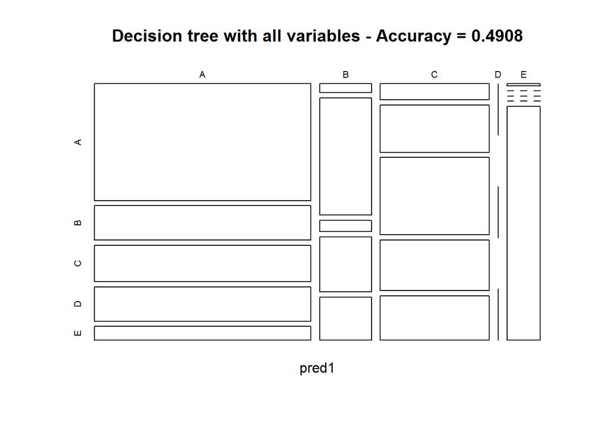

```r
# Plotting matrix
plot(confMat1$table, col = confMat1$byClass,
     main = paste("Decision tree with all variables - Accuracy =",
                  round(confMat1$overall['Accuracy'], 4)))
```

[figure not shown]

```r
tree2 <- train(classe ~ roll_belt +
                pitch_belt +
                yaw_belt +
                total_accel_belt +
                gyros_belt_x +
                gyros_belt_y +
                gyros_belt_z +
                accel_belt_x +
                accel_belt_y +
                accel_belt_z,
              method = 'rpart', data = training)
fancyRpartPlot(tree2$finalModel)
```

```r
# Predicting new values
pred2 <- predict(tree2, newdata = testing)
confMat2 <- confusionMatrix(table(pred2, testing$classe))
confMat2
```

```
## Confusion Matrix and Statistics
##
##
## pred2   A   B   C   D   E
##     A 834 568 513 434 236
##     B   0   0   0   0   0
##     C   0   0   0   0   0
##     D   0   0   0   0   0
##     E   3   1   0  48 305
##
## Overall Statistics
##
##                Accuracy : 0.3872
##                  95% CI : (0.3695, 0.405)
##     No Information Rate : 0.2845
##     P-Value [Acc > NIR] : < 2.2e-16
##
##                   Kappa : 0.1578
##
##  Mcnemar's Test P-Value : NA
##
## Statistics by Class:
##
##                      Class: A Class: B Class: C Class: D Class: E
## Sensitivity            0.9964   0.0000   0.0000   0.0000   0.5638
## Specificity            0.1682   1.0000   1.0000   1.0000   0.9783
## Pos Pred Value         0.3226      NaN      NaN      NaN   0.8543
## Neg Pred Value         0.9916   0.8066   0.8256   0.8362   0.9087
## Prevalence             0.2845   0.1934   0.1744   0.1638   0.1839
## Detection Rate         0.2835   0.0000   0.0000   0.0000   0.1037
## Detection Prevalence   0.8787   0.0000   0.0000   0.0000   0.1213
## Balanced Accuracy      0.5823   0.5000   0.5000   0.5000   0.7711
```

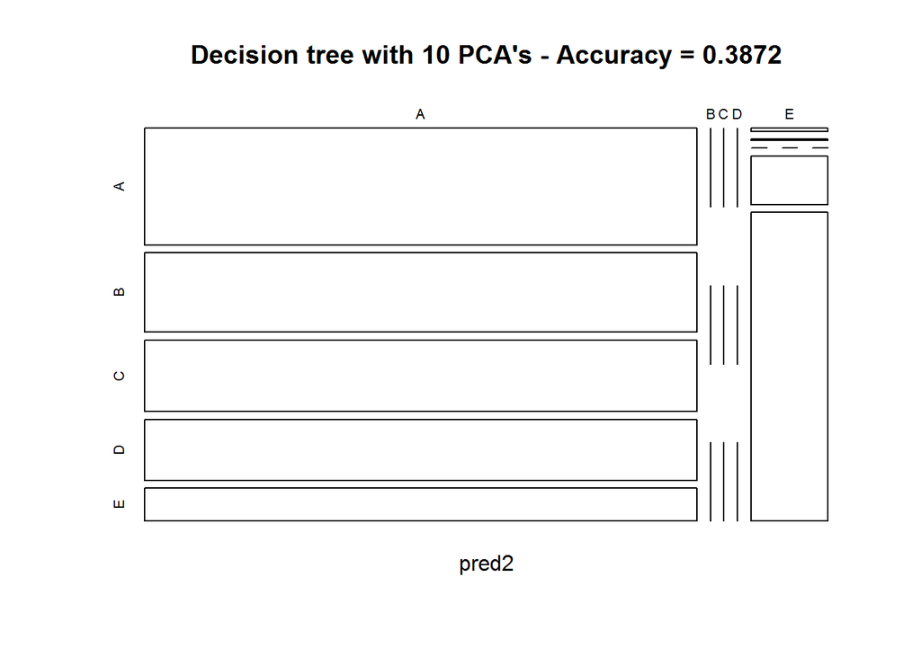

```r
# Plotting matrix
plot(confMat2$table, col = confMat2$byClass,
     main = paste("Decision tree with 10 PCA's - Accuracy =",
                  round(confMat2$overall['Accuracy'], 4)))
```

[figure not shown]

```r
tree3 <- train(classe ~ roll_belt +
                pitch_belt +
                yaw_belt +
                total_accel_belt +
                gyros_belt_x +
                gyros_belt_y +
                gyros_belt_z +
                accel_belt_x +
                accel_belt_y +
                accel_belt_z +
                magnet_belt_x +
                magnet_belt_y +
                magnet_belt_z +
                roll_arm +
                pitch_arm,
              method = 'rpart', data = training)
fancyRpartPlot(tree3$finalModel)
```

```r
# Predicting new values
pred3 <- predict(tree3, newdata = testing)
confMat3 <- confusionMatrix(table(pred3, testing$classe))
confMat3
```

```
## Confusion Matrix and Statistics
##
##
## pred3   A   B   C   D   E
##     A 565 152 112  34  48
##     B  86 380 144  10  90
##     C  39   2  79   1  21
##     D 144  34 178 389  77
##     E   3   1   0  48 305
##
## Overall Statistics
##
##                Accuracy : 0.584
##                  95% CI : (0.5659, 0.6018)
##     No Information Rate : 0.2845
##     P-Value [Acc > NIR] : < 2.2e-16
##
##                   Kappa : 0.4725
##
##  Mcnemar's Test P-Value : < 2.2e-16
##
## Statistics by Class:
##
##                      Class: A Class: B Class: C Class: D Class: E
## Sensitivity            0.6750   0.6678  0.15400   0.8071   0.5638
## Specificity            0.8356   0.8609  0.97406   0.8240   0.9783
## Pos Pred Value         0.6202   0.5352  0.55634   0.4732   0.8543
## Neg Pred Value         0.8661   0.9153  0.84500   0.9561   0.9087
## Prevalence             0.2845   0.1934  0.17437   0.1638   0.1839
## Detection Rate         0.1920   0.1292  0.02685   0.1322   0.1037
## Detection Prevalence   0.3097   0.2413  0.04827   0.2794   0.1213
## Balanced Accuracy      0.7553   0.7644  0.56403   0.8155   0.7711
```

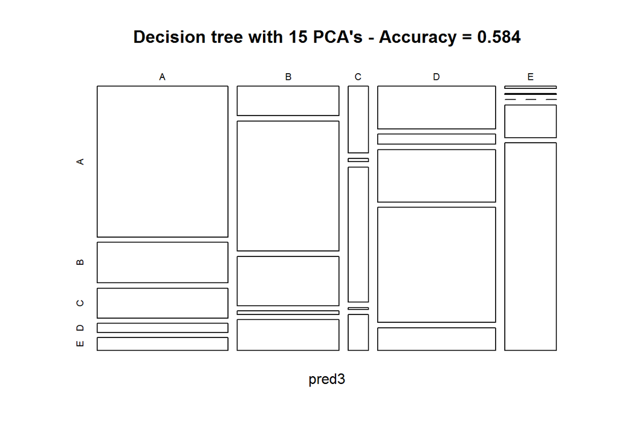

```r
# Plotting matrix
plot(confMat3$table, col = confMat3$byClass,
     main = paste("Decision tree with 15 PCA's - Accuracy =",
                  round(confMat3$overall['Accuracy'], 4)))
```

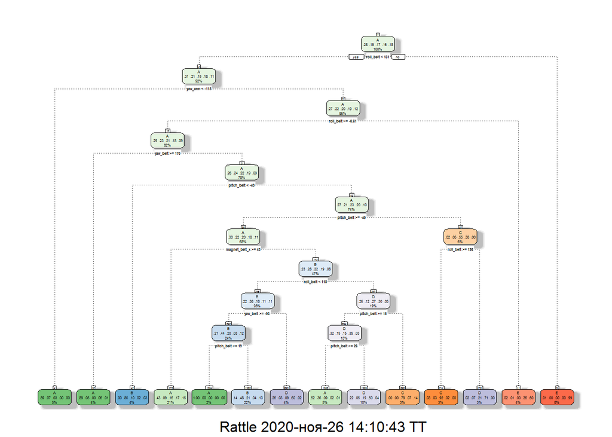

```r
tree4 <- train(classe ~ roll_belt +
                 pitch_belt +
                 yaw_belt +
                 total_accel_belt +
                 gyros_belt_x +
                 gyros_belt_y +
                 gyros_belt_z +
                 accel_belt_x +
                 accel_belt_y +
                 accel_belt_z +
                 magnet_belt_x +
                 magnet_belt_y +
                 magnet_belt_z +
                 roll_arm +
                 pitch_arm +
                 yaw_arm +
                 total_accel_arm +
                 gyros_arm_x +
                 gyros_arm_y +
                 gyros_arm_z,
              method = 'rpart', data = training)
fancyRpartPlot(tree4$finalModel)
```

```r
# Predicting new values
pred4 <- predict(tree4, newdata = testing)
confMat4 <- confusionMatrix(table(pred4, testing$classe))
confMat4
```

```
## Confusion Matrix and Statistics
##
##
## pred4   A   B   C   D   E
##     A 645 136 123 109 104
##     B  84 408 152  25 106
##     C   5   2 153  10  10
##     D 100  22  85 290  16
##     E   3   1   0  48 305
##
## Overall Statistics
##
##                Accuracy : 0.6122
##                  95% CI : (0.5943, 0.6298)
##     No Information Rate : 0.2845
##     P-Value [Acc > NIR] : < 2.2e-16
##
##                   Kappa : 0.5025
##
##  Mcnemar's Test P-Value : < 2.2e-16
##
## Statistics by Class:
##
##                      Class: A Class: B Class: C Class: D Class: E
## Sensitivity            0.7706   0.7170  0.29825  0.60166   0.5638
## Specificity            0.7758   0.8453  0.98888  0.90935   0.9783
## Pos Pred Value         0.5774   0.5265  0.85000  0.56530   0.8543
## Neg Pred Value         0.8948   0.9257  0.86966  0.92096   0.9087
## Prevalence             0.2845   0.1934  0.17437  0.16383   0.1839
## Detection Rate         0.2192   0.1387  0.05201  0.09857   0.1037
## Detection Prevalence   0.3797   0.2634  0.06118  0.17437   0.1213
## Balanced Accuracy      0.7732   0.7812  0.64356  0.75550   0.7711
```

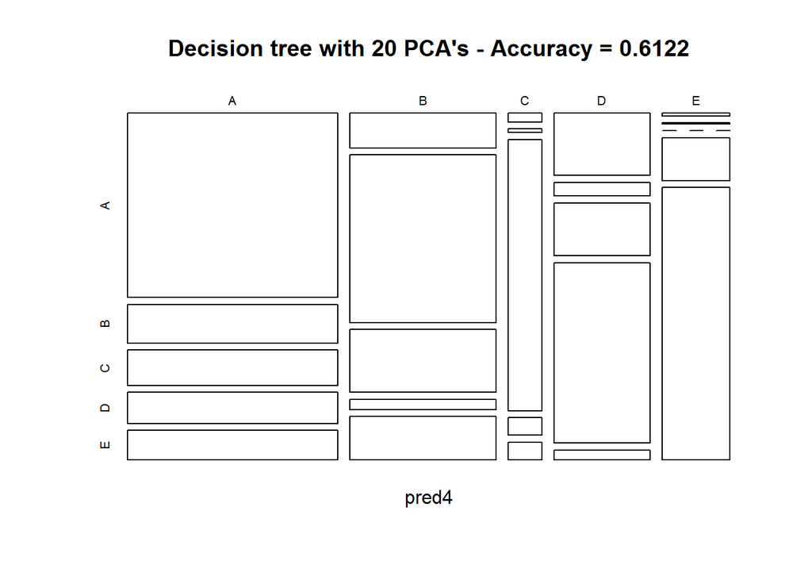

```r
# Plotting matrix
plot(confMat4$table, col = confMat4$byClass,
     main = paste("Decision tree with 20 PCA's - Accuracy =",
                  round(confMat4$overall['Accuracy'], 4)))
```

### Generalized Boosted Model (GBM) with all columns

```r
gbm1 <- train(classe ~ ., method = 'gbm', data = training, verbose = FALSE)
print(gbm1)
```

```
## Stochastic Gradient Boosting
##
## 16680 samples
##    52 predictor
##     5 classes: 'A', 'B', 'C', 'D', 'E'
##
## No pre-processing
## Resampling: Bootstrapped (25 reps)
## Summary of sample sizes: 16680, 16680, 16680, 16680, 16680, 16680, ...
## Resampling results across tuning parameters:
##
##   interaction.depth  n.trees  Accuracy   Kappa
##   1                   50      0.7515657  0.6849362
##   1                  100      0.8181052  0.7697238
##   1                  150      0.8523369  0.8130894
##   2                   50      0.8542794  0.8153345
##   2                  100      0.9054505  0.8803326
##   2                  150      0.9299389  0.9113370
##   3                   50      0.8944726  0.8663849
##   3                  100      0.9407331  0.9249930
##   3                  150      0.9589566  0.9480665
##
## Tuning parameter 'shrinkage' was held constant at a value of 0.1
##
## Tuning parameter 'n.minobsinnode' was held constant at a value of 10
## Accuracy was used to select the optimal model using the largest value.
## The final values used for the model were n.trees = 150, interaction.depth =
##  3, shrinkage = 0.1 and n.minobsinnode = 10.
```

```r
# Predicting new values
predGbm1 <- predict(gbm1, testing)
confMatGbm1 <- confusionMatrix(table(predGbm1, testing$classe))
confMatGbm1
```

```
## Confusion Matrix and Statistics
##
##
## predGbm1   A   B   C   D   E
##        A 827  16   0   1   0
##        B   8 534  14   0   4
##        C   2  18 491  18   2
##        D   0   1   6 461  13
##        E   0   0   2   2 522
##
## Overall Statistics
##
##                Accuracy : 0.9636
##                  95% CI : (0.9562, 0.9701)
##     No Information Rate : 0.2845
##     P-Value [Acc > NIR] : < 2.2e-16
##
##                   Kappa : 0.954
##
##  Mcnemar's Test P-Value : NA
##
## Statistics by Class:
##
##                      Class: A Class: B Class: C Class: D Class: E
## Sensitivity            0.9881   0.9385   0.9571   0.9564   0.9649
## Specificity            0.9919   0.9890   0.9835   0.9919   0.9983
## Pos Pred Value         0.9799   0.9536   0.9247   0.9584   0.9924
## Neg Pred Value         0.9952   0.9853   0.9909   0.9915   0.9921
## Prevalence             0.2845   0.1934   0.1744   0.1638   0.1839
## Detection Rate         0.2811   0.1815   0.1669   0.1567   0.1774
## Detection Prevalence   0.2869   0.1903   0.1805   0.1635   0.1788
## Balanced Accuracy      0.9900   0.9638   0.9703   0.9742   0.9816
```

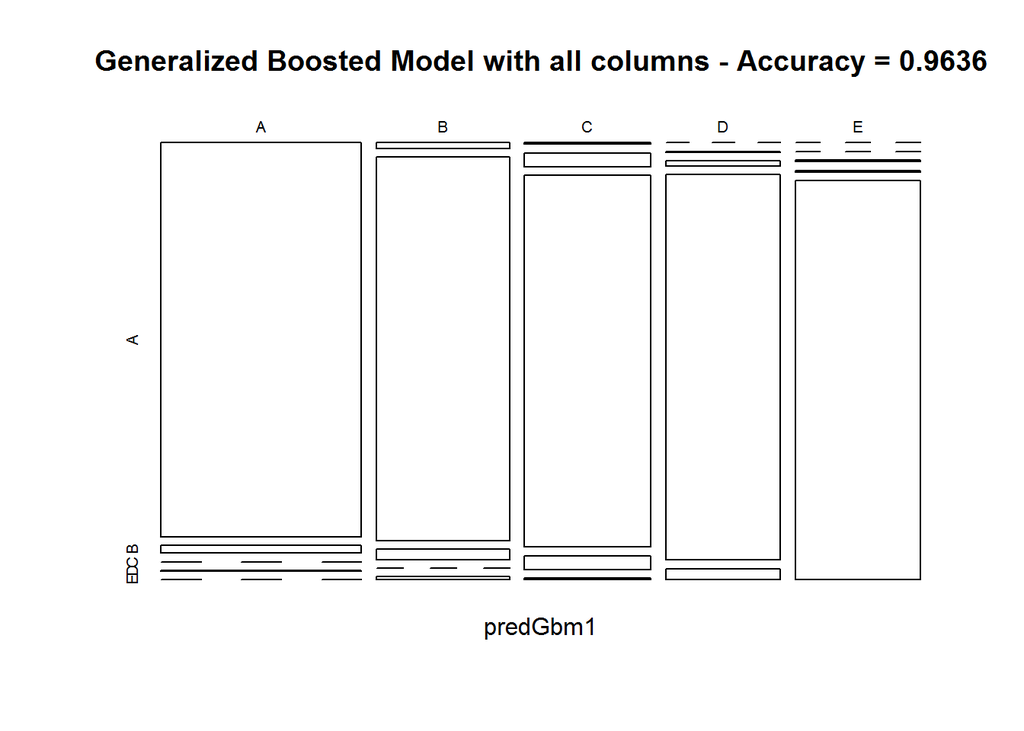

```r
# Plotting matrix
plot(confMatGbm1$table, col = confMatGbm1$byClass,
     main = paste("Generalized Boosted Model with all columns - Accuracy =",
                  round(confMatGbm1$overall['Accuracy'], 4)))
```

```r
gbm2 <- train(classe ~ roll_belt +
                 pitch_belt +
                 yaw_belt +
                 total_accel_belt +
                 gyros_belt_x +
                 gyros_belt_y +
                 gyros_belt_z +
                 accel_belt_x +
                 accel_belt_y +
                 accel_belt_z +
                 magnet_belt_x +
                 magnet_belt_y +
                 magnet_belt_z +
                 roll_arm +
                 pitch_arm +
                 yaw_arm +
                 total_accel_arm +
                 gyros_arm_x +
                 gyros_arm_y +
                 gyros_arm_z,
              method = 'gbm', data = training, verbose = FALSE)
print(gbm2)
```

```
## Stochastic Gradient Boosting
##
## 16680 samples
##    20 predictor
##     5 classes: 'A', 'B', 'C', 'D', 'E'
##
## No pre-processing
## Resampling: Bootstrapped (25 reps)
## Summary of sample sizes: 16680, 16680, 16680, 16680, 16680, 16680, ...
## Resampling results across tuning parameters:
##
##   interaction.depth  n.trees  Accuracy   Kappa
##   1                   50      0.6112899  0.4973443
##   1                  100      0.6794742  0.5896588
##   1                  150      0.7120616  0.6328605
##   2                   50      0.7341208  0.6617683
##   2                  100      0.7941076  0.7388987
##   2                  150      0.8258835  0.7793899
##   3                   50      0.7897054  0.7333362
##   3                  100      0.8432675  0.8015155
##   3                  150      0.8701110  0.8355883
##
## Tuning parameter 'shrinkage' was held constant at a value of 0.1
##
## Tuning parameter 'n.minobsinnode' was held constant at a value of 10
## Accuracy was used to select the optimal model using the largest value.
## The final values used for the model were n.trees = 150, interaction.depth =
##  3, shrinkage = 0.1 and n.minobsinnode = 10.
```

```r
# Predicting new values
predGbm2 <- predict(gbm2, testing)
confMatGbm2 <- confusionMatrix(table(predGbm2, testing$classe))
confMatGbm2
```

```
## Confusion Matrix and Statistics
##
##
## predGbm2   A   B   C   D   E
##        A 763  34  11  20  20
##        B  28 487  55   3  17
##        C  11  39 418  24   9
##        D  28   4  28 430   9
##        E   7   5   1   5 486
##
## Overall Statistics
##
##                Accuracy : 0.8783
##                  95% CI : (0.866, 0.8899)
##     No Information Rate : 0.2845
##     P-Value [Acc > NIR] : < 2.2e-16
##
##                   Kappa : 0.846
##
##  Mcnemar's Test P-Value : 0.004578
##
## Statistics by Class:
##
##                      Class: A Class: B Class: C Class: D Class: E
## Sensitivity            0.9116   0.8559   0.8148   0.8921   0.8983
## Specificity            0.9596   0.9566   0.9658   0.9720   0.9925
## Pos Pred Value         0.8998   0.8254   0.8343   0.8617   0.9643
## Neg Pred Value         0.9647   0.9651   0.9611   0.9787   0.9774
## Prevalence             0.2845   0.1934   0.1744   0.1638   0.1839
## Detection Rate         0.2593   0.1655   0.1421   0.1462   0.1652
## Detection Prevalence   0.2882   0.2005   0.1703   0.1696   0.1713
## Balanced Accuracy      0.9356   0.9062   0.8903   0.9320   0.9454
```

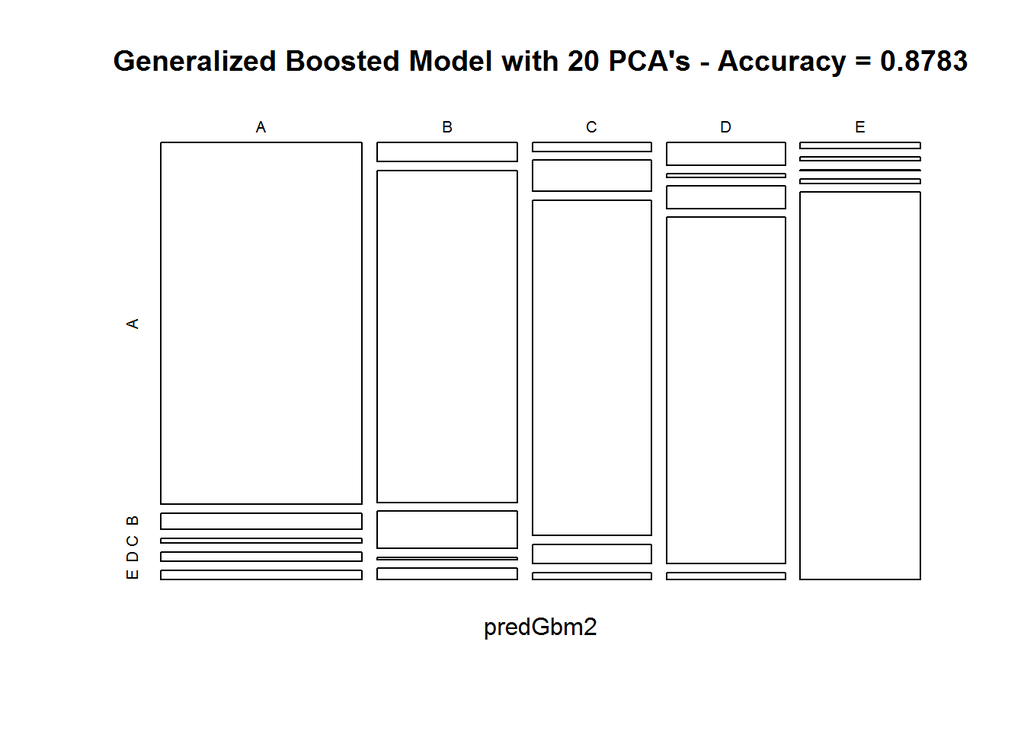

```r
# Plotting matrix
plot(confMatGbm2$table, col = confMatGbm2$byClass,
     main = paste("Generalized Boosted Model with 20 PCA's - Accuracy =",
                  round(confMatGbm2$overall['Accuracy'], 4)))
```

### Random forest

```r
forest <- train(classe ~ ., method = 'rf', data = training)
print(forest$finalModel)
```

```
##
## Call:
##  randomForest(x = x, y = y, mtry = param$mtry)
##                Type of random forest: classification
##                      Number of trees: 500
## No. of variables tried at each split: 27
##
##         OOB estimate of  error rate: 0.58%
## Confusion matrix:
##      A    B    C    D    E class.error
## A 4737    5    1    0    0 0.001265022
## B   20 3202    6    0    0 0.008054523
## C    0   15 2885    9    0 0.008250258
## D    0    0   26 2706    2 0.010241405
## E    0    0    5    7 3054 0.003913894
```

```r
# Predicting new values
predFor <- predict(forest, newdata = testing)
confMatFor <- confusionMatrix(table(predFor, testing$classe))
confMatFor
```

```
## Confusion Matrix and Statistics
##
##
## predFor   A   B   C   D   E
##       A 833   1   0   0   0
##       B   3 567   1   0   1
##       C   0   1 512   5   1
##       D   0   0   0 477   4
##       E   1   0   0   0 535
##
## Overall Statistics
##
##                Accuracy : 0.9939
##                  95% CI : (0.9903, 0.9964)
##     No Information Rate : 0.2845
##     P-Value [Acc > NIR] : < 2.2e-16
##
##                   Kappa : 0.9923
##
##  Mcnemar's Test P-Value : NA
##
## Statistics by Class:
##
##                      Class: A Class: B Class: C Class: D Class: E
## Sensitivity            0.9952   0.9965   0.9981   0.9896   0.9889
## Specificity            0.9995   0.9979   0.9971   0.9984   0.9996
## Pos Pred Value         0.9988   0.9913   0.9865   0.9917   0.9981
## Neg Pred Value         0.9981   0.9992   0.9996   0.9980   0.9975
## Prevalence             0.2845   0.1934   0.1744   0.1638   0.1839
## Detection Rate         0.2831   0.1927   0.1740   0.1621   0.1818
## Detection Prevalence   0.2835   0.1944   0.1764   0.1635   0.1822
## Balanced Accuracy      0.9974   0.9972   0.9976   0.9940   0.9942
```

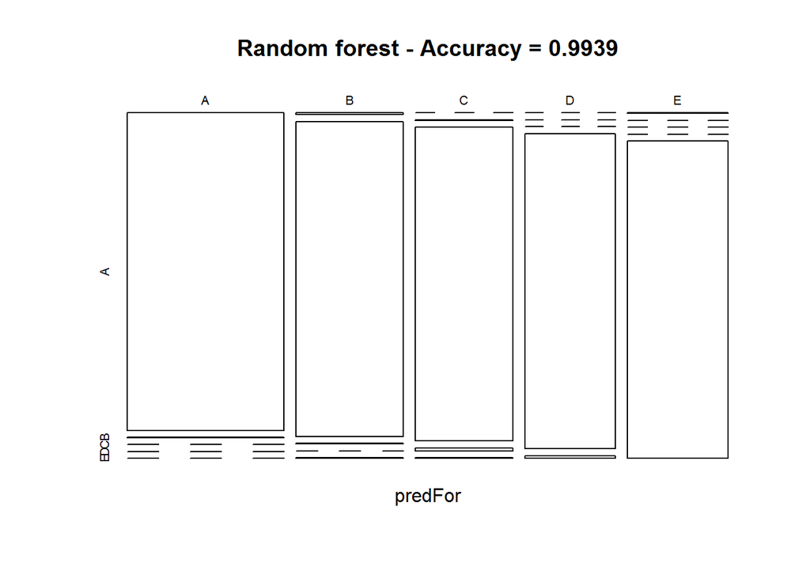

```r
# Plotting matrix
plot(confMatFor$table, col = confMatFor$byClass,
     main = paste("Random forest - Accuracy =",
                  round(confMatFor$overall['Accuracy'], 4)))
```

## Choosing and applying model for validation set

The best score was shown by Random forest, so this model will be used with accuracy = 99.39%.

```r
predValidation <- predict(forest, newdata = validation)
predValidation
```

```
##  [1] B A B A A E D B A A B C B A E E A B B B
## Levels: A B C D E
```